# Стоимость аренды квартиры

**AI Challenge 2026 — квалификационный этап**

Задача: по площади, району, этажу и удалённости от центра предсказать месячную арендную ставку.

Главный вывод этой работы, если читать только его: **данные синтетические, и порождающую их формулу можно восстановить почти целиком.** Из-за этого задача решается не градиентным бустингом, как обычно бывает с таблицами, а маленькой параметрической моделью из полусотни коэффициентов — и она обходит LightGBM примерно на 10 % по RMSE.

## Содержание

1. Загрузка и проверка данных
2. Разведочный анализ
3. Как устроены данные: восстанавливаем формулу
4. Схема валидации
5. Бенчмарк моделей
6. Финальная модель
7. Диагностика и потолок качества
8. Сабмит
9. Выводы

## 1. Загрузка и проверка данных

Файлы в архиве лежат без расширений, но внутри это обычный CSV — `pandas` читает их как есть.

```python
import numpy as np
import pandas as pd
import matplotlib.pyplot as plt
from matplotlib.colors import LinearSegmentedColormap
import warnings
from pathlib import Path

warnings.filterwarnings("ignore")
pd.set_option("display.width", 120)

# --- единый стиль графиков на всю тетрадь ---
INK, MUTED, GRID = "#131A16", "#5E6A62", "#D6DDD4"
ACCENT = "#0E6B57"
RAMP = LinearSegmentedColormap.from_list("viridian", ["#CFE3DA", "#0A4C3E"])

plt.rcParams.update({
    "figure.dpi": 110, "savefig.dpi": 110,
    "font.size": 9.5, "axes.titlesize": 10.5, "axes.titleweight": "bold",
    "axes.labelcolor": MUTED, "axes.edgecolor": GRID, "axes.titlecolor": INK,
    "text.color": INK, "xtick.color": MUTED, "ytick.color": MUTED,
    "axes.grid": True, "grid.color": GRID, "grid.linewidth": .7, "grid.alpha": .8,
    "axes.spines.top": False, "axes.spines.right": False,
    "figure.facecolor": "white", "axes.facecolor": "white",
})

DATA = Path("..") / "data"      # данные лежат рядом с ноутбуком, в папке data/

train = pd.read_csv(DATA / "train")
test = pd.read_csv(DATA / "test")
sample = pd.read_csv(DATA / "sample_submission")

print("train:", train.shape, "| test:", test.shape, "| sample_submission:", sample.shape)
train.head()
```

```
train: (7000, 6) | test: (2000, 5) | sample_submission: (2000, 2)
```

|  | id | area | district | floor | distance_to_center | rent_price |
| --- | --- | --- | --- | --- | --- | --- |
| 0 | 0 | 84.2 | suburb | 4 | 11.59 | 2485.07 |
| 1 | 1 | 66.8 | suburb | 3 | 5.85 | 1383.59 |
| 2 | 2 | 61.1 | central | 11 | 1.43 | 2497.48 |
| 3 | 3 | 86.2 | residential | 14 | 5.64 | 2710.22 |
| 4 | 4 | 50.5 | central | 5 | 1.21 | 1494.48 |

### Что сразу нужно проверить

Три вещи, которые определяют, можно ли доверять валидации: пропуски, дубликаты и сдвиг распределений между train и test.

```python
print("Пропуски в train:", train.isna().sum().sum(), "| в test:", test.isna().sum().sum())
print("Полных дубликатов (без id):", train.drop(columns="id").duplicated().sum())
print("id train:", train.id.min(), "-", train.id.max(), "| id test:", test.id.min(), "-", test.id.max())
print("Корреляция id с таргетом: %.4f  (утечки через порядок строк нет)"
      % np.corrcoef(train.id, train.rent_price)[0, 1])

print("\nСдвиг распределений train vs test:")
for c in ["area", "floor", "distance_to_center"]:
    print(f"  {c:20s} train {train[c].mean():7.2f}   test {test[c].mean():7.2f}")

shift = (test.district.value_counts(normalize=True)
         - train.district.value_counts(normalize=True)) * 100
print(f"\nМаксимальное расхождение долей районов: {shift.abs().max():.2f} п.п.")
```

```
Пропуски в train: 0 | в test: 0
Полных дубликатов (без id): 0
id train: 0 - 6999 | id test: 7000 - 8999
Корреляция id с таргетом: -0.0086  (утечки через порядок строк нет)

Сдвиг распределений train vs test:
  area                 train   69.68   test   70.51
  floor                train    9.36   test    9.60
  distance_to_center   train    6.37   test    6.41

Максимальное расхождение долей районов: 0.95 п.п.
```

Пропусков нет, дубликатов нет, `id` с таргетом не связан, распределения признаков в train и test совпадают. Значит, обычный `KFold` даст честную оценку — никаких стратификаций и группировок не нужно.

### Формат ответа

В `sample_submission` во всех 2000 строках стоит одно и то же число. Проверим, что это.

```python
print("Уникальных значений в sample_submission:", sample.rent_price.nunique())
print("Это значение:      ", sample.rent_price.iloc[0])
print("Среднее по train:  ", train.rent_price.mean())
print("Порядок id совпадает с test:", (sample.id.values == test.id.values).all())
```

```
Уникальных значений в sample_submission: 1
Это значение:       3193.2396185714283
Среднее по train:   3193.2396185714283
Порядок id совпадает с test: True
```

Организаторы дали константный baseline — среднее по train. Его R² на тесте будет примерно 0, и это нижняя планка, которую нужно уверенно обойти.

## 2. Разведочный анализ

### 2.1 Таргет

Арендная ставка — величина с тяжёлым правым хвостом: большинство квартир стоит около 2500, но есть единицы за десятки тысяч.

```
count     7000.0
mean      3193.2
std       3080.4
min        350.0
25%       1888.8
50%       2566.0
75%       3504.4
max      66216.6

Асимметрия (skew): 6.62
Ровно 350.00 (минимум) встречается 36 раз — таргет обрезан снизу
```

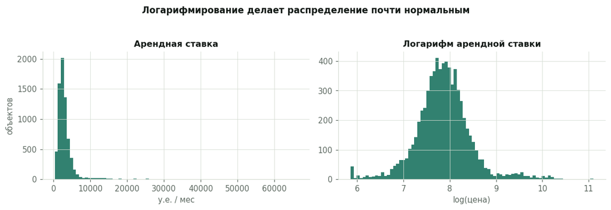

```python
y = train.rent_price
print(y.describe().round(1).to_string())
print(f"\nАсимметрия (skew): {y.skew():.2f}")
print(f"Ровно 350.00 (минимум) встречается {int((y == 350).sum())} раз — таргет обрезан снизу")

fig, ax = plt.subplots(1, 2, figsize=(10.5, 3.4))
ax[0].hist(y, bins=80, color=ACCENT, alpha=.85)
ax[0].set_title("Арендная ставка"); ax[0].set_xlabel("у.е. / мес"); ax[0].set_ylabel("объектов")
ax[1].hist(np.log(y), bins=80, color=ACCENT, alpha=.85)
ax[1].set_title("Логарифм арендной ставки"); ax[1].set_xlabel("log(цена)")
fig.suptitle("Логарифмирование делает распределение почти нормальным",
             fontsize=11, fontweight="bold", y=1.04, color=INK)
plt.tight_layout(); plt.show()
```

Слева — длинный хвост, из-за которого одна дорогая квартира может перевесить сотню обычных. Справа — почти симметричный колокол. Это первый намёк: **работать нужно с логарифмом цены**, а не с самой ценой.

### 2.2 Район — главный признак

```
              объектов  медиана  среднее
district
industrial         595   1395.0   1422.0
suburb             993   2052.0   2153.0
residential       1241   2095.0   2167.0
green_zone         511   2481.0   2592.0
university         821   2553.0   2659.0
riverside          583   2870.0   3002.0
old_town           528   2931.0   3084.0
business           768   3548.0   3712.0
central            690   4079.0   4196.0
luxury_hills       270  12951.0  14992.0
```

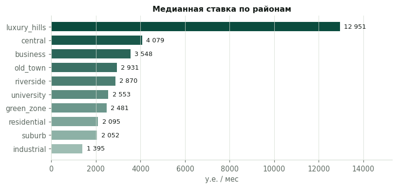

```python
dist_stats = (train.groupby("district")
              .agg(объектов=("rent_price", "size"),
                   медиана=("rent_price", "median"),
                   среднее=("rent_price", "mean"))
              .sort_values("медиана"))
print(dist_stats.round(0).to_string())

fig, ax = plt.subplots(figsize=(7.5, 3.6))
vals = dist_stats["медиана"].values
colors = RAMP(np.linspace(.25, 1, len(vals)))
ax.barh(dist_stats.index, vals, color=colors, height=.68)
for i, v in enumerate(vals):
    ax.text(v + 180, i, f"{v:,.0f}".replace(",", " "), va="center", fontsize=8.5, color=INK)
ax.set_xlim(0, vals.max() * 1.18)
ax.set_title("Медианная ставка по районам")
ax.set_xlabel("у.е. / мес"); ax.grid(axis="y", visible=False)
plt.tight_layout(); plt.show()
```

Разрыв между самым дешёвым и самым дорогим районом — более чем девятикратный. `luxury_hills` стоит особняком: там всего 270 объектов, но именно они дают весь верхний хвост цен.

### 2.3 Площадь — и первая неожиданность

Логично ожидать, что цена растёт с площадью. Посмотрим, так ли это **внутри каждого района**.

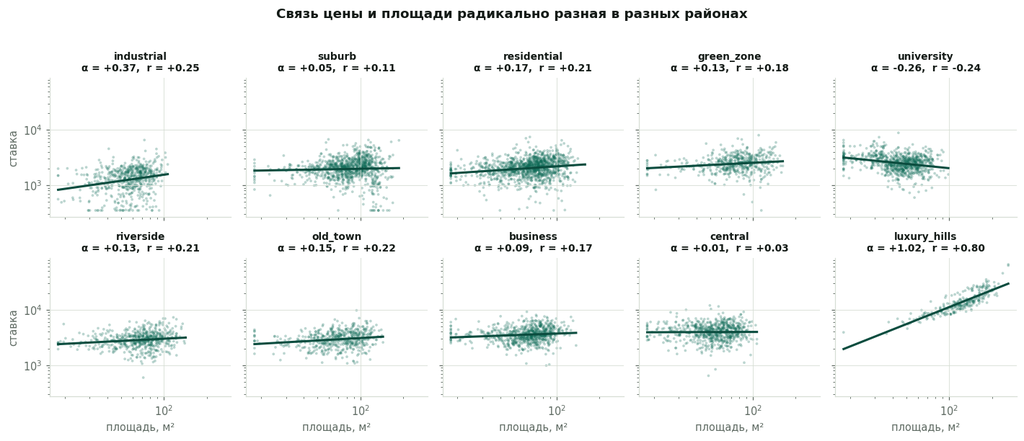

```python
order = dist_stats.index.tolist()
fig, axes = plt.subplots(2, 5, figsize=(13, 5.4), sharex=True, sharey=True)

for ax, d in zip(axes.ravel(), order):
    g = train[train.district == d]
    ax.scatter(g.area, g.rent_price, s=6, color=ACCENT, alpha=.28, edgecolors="none")
    # линия тренда в лог-лог координатах
    b = np.polyfit(np.log(g.area), np.log(g.rent_price), 1)
    xs = np.linspace(g.area.min(), g.area.max(), 50)
    ax.plot(xs, np.exp(np.polyval(b, np.log(xs))), color="#0A4C3E", lw=2)
    r = np.corrcoef(g.area, g.rent_price)[0, 1]
    ax.set_title(f"{d}\nα = {b[0]:+.2f},  r = {r:+.2f}", fontsize=9)
    ax.set_yscale("log"); ax.set_xscale("log")

for ax in axes[1]: ax.set_xlabel("площадь, м²")
for ax in axes[:, 0]: ax.set_ylabel("ставка")
fig.suptitle("Связь цены и площади радикально разная в разных районах",
             fontsize=12, fontweight="bold", y=1.02, color=INK)
plt.tight_layout(); plt.show()
```

Вот это и есть ключ ко всей задаче.

- В **`luxury_hills`** α ≈ +1.0 — цена почти пропорциональна метражу, как и должно быть в жизни.
- В **`central`** α ≈ 0.0 — площадь не влияет на цену **вообще**.
- В **`university`** α отрицательная: большие квартиры дешевле маленьких.

Последнее физически бессмысленно и прямо говорит, что данные сгенерированы формулой, а не собраны с реального рынка. Но для нас важно другое: модель, которая не умеет по-разному реагировать на площадь в разных районах, обречена. Нужно взаимодействие **`district` × `area`**.

### 2.4 Удалённость от центра и этаж

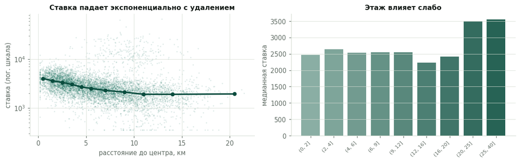

```
Корреляция log(цена) с расстоянием: -0.329
Корреляция log(цена) с этажом:      +0.087
```

```python
fig, ax = plt.subplots(1, 2, figsize=(11, 3.5))

# расстояние: медиана по корзинам
bins = pd.cut(train.distance_to_center, [0, 1, 2, 3, 4, 5, 6, 8, 10, 12, 16, 25])
med = train.groupby(bins, observed=True).rent_price.median()
centers = [iv.mid for iv in med.index]
ax[0].scatter(train.distance_to_center, train.rent_price, s=4, color=ACCENT, alpha=.13, edgecolors="none")
ax[0].plot(centers, med.values, color="#0A4C3E", lw=2.2, marker="o", ms=5)
ax[0].set_yscale("log"); ax[0].set_title("Ставка падает экспоненциально с удалением")
ax[0].set_xlabel("расстояние до центра, км"); ax[0].set_ylabel("ставка (лог. шкала)")

# этаж
fb = pd.cut(train.floor, [0, 2, 4, 6, 9, 12, 16, 20, 25, 40])
medf = train.groupby(fb, observed=True).rent_price.median()
ax[1].bar(range(len(medf)), medf.values, color=RAMP(np.linspace(.35, .85, len(medf))))
ax[1].set_xticks(range(len(medf)))
ax[1].set_xticklabels([str(i) for i in medf.index], rotation=45, ha="right", fontsize=7.5)
ax[1].set_title("Этаж влияет слабо"); ax[1].set_ylabel("медианная ставка")
ax[1].grid(axis="x", visible=False)
plt.tight_layout(); plt.show()

print("Корреляция log(цена) с расстоянием: %+.3f" % np.corrcoef(train.distance_to_center, np.log(y))[0, 1])
print("Корреляция log(цена) с этажом:      %+.3f" % np.corrcoef(train.floor, np.log(y))[0, 1])
```

## 3. Как устроены данные: восстанавливаем формулу

Соберём наблюдения вместе. Цена ведёт себя как **произведение** факторов: район задаёт базовый уровень, площадь входит степенью, расстояние — экспонентой. Если взять логарифм, произведение превращается в сумму, и всё становится линейным:

$$\log(\text{price}) = \underbrace{a_d}_{\text{район}} + \underbrace{\alpha_d \log(\text{area})}_{\text{площадь}} - \underbrace{\beta_d \cdot \text{distance}}_{\text{удалённость}} + \underbrace{\gamma_d \log(1+\text{floor})}_{\text{этаж}} + \varepsilon$$

Индекс $d$ означает, что **у каждого района свой набор коэффициентов**. Оценим их обычным методом наименьших квадратов.

```python
DISTRICTS = sorted(train.district.unique())
LOG_AREA_CENTER = 4.2   # ≈ log(66 м²) — центрируем, чтобы свободный член имел смысл

def make_basis(df, deg=3):
    """Блочная матрица признаков: каждый признак умножен на one-hot района.
    В результате у каждого района получаются свои собственные коэффициенты."""
    D = (pd.get_dummies(df.district)
           .reindex(columns=DISTRICTS, fill_value=0)
           .astype(float).values)
    log_area = np.log(df.area.values) - LOG_AREA_CENTER
    blocks = [D]
    for k in range(1, deg + 1):
        blocks.append(D * (log_area ** k)[:, None])
    blocks.append(D * df.distance_to_center.values[:, None])
    blocks.append(D * np.log1p(df.floor.values)[:, None])
    return np.hstack(blocks)

# простая версия (deg=1) — чтобы коэффициенты читались напрямую
A = make_basis(train, deg=1)
coef, *_ = np.linalg.lstsq(A, np.log(train.rent_price.values), rcond=None)
k = len(DISTRICTS)

table = pd.DataFrame({
    "объектов": train.district.value_counts().reindex(DISTRICTS).values,
    "базовая ставка (66 м²)": np.exp(coef[:k]).round(0),
    "α — эластичность по площади": coef[k:2*k].round(2),
    "β — % цены за км": ((np.exp(coef[2*k:3*k]) - 1) * 100).round(1),
    "γ — этаж": coef[3*k:4*k].round(3),
}, index=DISTRICTS).sort_values("базовая ставка (66 м²)")
table
```

|  | объектов | базовая ставка (66 м²) | α — эластичность по площади | β — % цены за км | γ — этаж |
| --- | --- | --- | --- | --- | --- |
| university | 821 | 2352.0 | -0.27 | -2.8 | 0.037 |
| industrial | 595 | 2373.0 | 0.37 | -4.2 | -0.069 |
| residential | 1241 | 2520.0 | 0.17 | -2.8 | -0.006 |
| suburb | 993 | 2575.0 | 0.04 | -2.8 | 0.029 |
| green_zone | 511 | 2930.0 | 0.13 | -3.2 | 0.029 |
| riverside | 583 | 3425.0 | 0.14 | -3.3 | 0.001 |
| central | 690 | 3553.0 | -0.00 | -4.4 | 0.079 |
| old_town | 528 | 3587.0 | 0.15 | -3.1 | -0.081 |
| business | 768 | 3681.0 | 0.09 | -4.8 | 0.052 |
| luxury_hills | 270 | 7916.0 | 1.02 | -1.5 | 0.032 |

Таблица читается как описание вымышленного города:

- `luxury_hills` — премиальный район на холмах: базовая ставка вдвое выше любой другой, цена растёт строго пропорционально площади (α ≈ 1), а удалённость от центра почти не важна (β всего −1.5 %).
- `business` и `central` — деловой центр: дорогие, и цена быстрее всего падает при удалении (−4.8 % и −4.4 % за км).
- `university` — студенческий район с отрицательной α: чем больше квартира, тем дешевле метр *и* дешевле сама квартира. В реальности так не бывает; это артефакт генератора данных.

Теперь оценим шум — то, что формула объяснить не может.

```
Стандартное отклонение остатков в логарифмах: 0.367
То есть типичное отклонение цены от формулы: ±44 %

luxury_hills    0.231
business        0.293
riverside       0.322
old_town        0.327
university      0.330
green_zone      0.339
central         0.340
residential     0.371
suburb          0.443
industrial      0.507
```

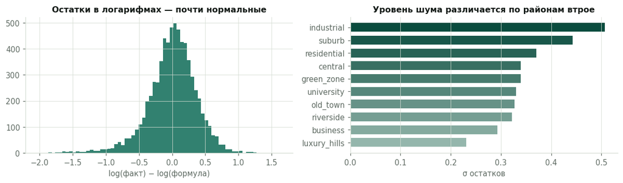

```python
resid = np.log(train.rent_price.values) - A @ coef
sigma_by_district = pd.Series(resid).groupby(train.district.values).std().sort_values()

print("Стандартное отклонение остатков в логарифмах: %.3f" % resid.std())
print("То есть типичное отклонение цены от формулы: ±%.0f %%\n" % ((np.exp(resid.std()) - 1) * 100))
print(sigma_by_district.round(3).to_string())

fig, ax = plt.subplots(1, 2, figsize=(11, 3.3))
ax[0].hist(resid, bins=70, color=ACCENT, alpha=.85)
ax[0].set_title("Остатки в логарифмах — почти нормальные"); ax[0].set_xlabel("log(факт) − log(формула)")
c = RAMP(np.linspace(.3, 1, len(sigma_by_district)))
ax[1].barh(sigma_by_district.index, sigma_by_district.values, color=c, height=.68)
ax[1].set_title("Уровень шума различается по районам втрое")
ax[1].set_xlabel("σ остатков"); ax[1].grid(axis="y", visible=False)
plt.tight_layout(); plt.show()
```

Обратите внимание и на форму распределения остатков — оно скошено влево. Это следствие обрезки цены снизу на 350, и в разделе 5 из этого вырастет вполне ощутимый выигрыш в метрике.

## 4. Метрика конкурса и схема валидации

Организаторы оценивают решения по **MAE** — средней абсолютной ошибке, — а балл считают по формуле

$$\text{points} = \max\left(0,\ 1 - \frac{\text{MAE}}{1500}\right)$$

При MAE больше 1500 участник получает ноль и не проходит квалификацию. Полезный ориентир: **каждые 15 единиц MAE — это ровно 0.01 балла.** Константный baseline организаторов даёт MAE ≈ 1510, то есть почти ноль; значит, всё, что мы выигрываем, идёт сразу в зачёт.

Остальные метрики считаем заодно, чтобы видеть картину целиком. Чтобы одна дорогая квартира в неудачном фолде не искажала оценку, берём **повторную** кросс-валидацию: 5 фолдов × 4 повтора = 20 замеров, усредняем.

```python
from sklearn.model_selection import RepeatedKFold
from sklearn.metrics import mean_squared_error, mean_absolute_error, r2_score

PRICE_FLOOR = 350.0   # в train цена обрезана снизу этим значением
MAE_SCALE = 1500.0    # из формулы баллов квалификационного этапа

CV = RepeatedKFold(n_splits=5, n_repeats=4, random_state=7)
SPLITS = list(CV.split(train))
Y = train.rent_price.values
LOG_Y = np.log(Y)

def points(mae):
    """Балл конкурса по значению MAE."""
    return max(0.0, 1.0 - mae / MAE_SCALE)

def score(y_true, y_pred):
    y_pred = np.clip(y_pred, PRICE_FLOOR, None)
    mae = mean_absolute_error(y_true, y_pred)
    return np.array([
        mae, points(mae),
        np.sqrt(mean_squared_error(y_true, y_pred)),
        r2_score(y_true, y_pred),
        np.mean(np.abs(y_true - y_pred) / y_true) * 100,
    ])

METRICS = ["MAE", "баллы", "RMSE", "R²", "MAPE"]
results = {}

def evaluate(name, predict_fn):
    """predict_fn(train_idx, valid_idx) -> предсказания на валидации"""
    folds = np.array([score(Y[va], predict_fn(tr, va)) for tr, va in SPLITS])
    results[name] = folds.mean(axis=0)
    r = results[name]
    print(f"{name:38s} MAE {r[0]:7.1f}   балл {r[1]:.4f}   RMSE {r[2]:7.1f}   R² {r[3]:.3f}")
    return folds[:, 0]   # MAE по фолдам — пригодится для парных сравнений
```

## 5. Бенчмарк моделей

Идём от самого простого к сложному, чтобы видеть, что именно даёт прирост.

```python
# 0. Константа — то же, что в sample_submission
evaluate("Константа (baseline организаторов)",
         lambda tr, va: np.full(len(va), Y[tr].mean()))

# 1. Медиана по району
evaluate("Медиана по району",
         lambda tr, va: train.district.iloc[va]
                        .map(train.iloc[tr].groupby("district").rent_price.median()).values)
```

```
Константа (baseline организаторов)     MAE  1509.8   балл 0.0083   RMSE  3065.5   R² -0.000
Медиана по району                      MAE   898.5   балл 0.4010   RMSE  1838.1   R² 0.643
```

```
array([848.26982857, 960.15323929, 910.10021429, 885.38478929,
       886.08058214, 954.81928929, 842.93314643, 862.17336786,
       877.55547143, 959.67961071, 912.14013214, 934.72082143,
       901.57619286, 852.75867857, 889.15388214, 881.73254286,
       875.13780357, 920.86566071, 934.08345357, 881.32842857])
```

```python
from sklearn.linear_model import Ridge

X_onehot = pd.get_dummies(train[["area", "floor", "distance_to_center", "district"]],
                          columns=["district"])

# 2. Линейная модель по сырой цене
evaluate("Ridge, сырая цена",
         lambda tr, va: Ridge().fit(X_onehot.iloc[tr], Y[tr]).predict(X_onehot.iloc[va]))

# 3. Та же модель, но по логарифму цены
evaluate("Ridge, log(цена)",
         lambda tr, va: np.exp(Ridge().fit(X_onehot.iloc[tr], LOG_Y[tr])
                               .predict(X_onehot.iloc[va])))
```

```
Ridge, сырая цена                      MAE   943.8   балл 0.3708   RMSE  1715.7   R² 0.688
```

```
Ridge, log(цена)                       MAE   848.1   балл 0.4346   RMSE  1641.9   R² 0.715
```

```
array([804.85703579, 899.35083288, 863.91883022, 830.46874856,
       841.05908453, 883.1076232 , 806.14593446, 804.08618633,
       838.21899836, 910.57544606, 867.19495588, 877.53521057,
       855.38501908, 799.70716783, 840.77615841, 838.35134243,
       809.70758461, 872.12478593, 882.78408246, 835.65682115])
```

Переход к логарифму таргета сам по себе даёт заметный прирост. Но обе модели пока не умеют реагировать на площадь по-разному в разных районах. Добавим взаимодействия — соберём ту самую блочную конструкцию, где у каждого района свой набор коэффициентов.

```python
DISTRICTS = sorted(train.district.unique())
LOG_AREA_CENTER = 4.2   # ≈ log(66 м²) — центрируем, чтобы свободный член имел смысл

def make_basis(df, degree=3):
    """Блочная матрица признаков: каждый признак умножается на one-hot района.
    В результате МНК оценивает отдельные коэффициенты для каждого района."""
    D = (pd.get_dummies(df.district)
           .reindex(columns=DISTRICTS, fill_value=0)
           .astype(float).values)
    log_area = np.log(df.area.values) - LOG_AREA_CENTER

    blocks = [D]
    for power in range(1, degree + 1):
        blocks.append(D * (log_area ** power)[:, None])
    blocks.append(D * df.distance_to_center.values[:, None])
    blocks.append(D * np.log1p(df.floor.values)[:, None])
    return np.hstack(blocks)

def least_squares(degree):
    """МНК в логарифмах, обратно берём условное среднее exp(mu + sigma^2/2)."""
    def predict(tr, va):
        A = make_basis(train.iloc[tr], degree)
        beta = np.linalg.lstsq(A, LOG_Y[tr], rcond=None)[0]
        sigma = (LOG_Y[tr] - A @ beta).std()
        return np.exp(make_basis(train.iloc[va], degree) @ beta + 0.5 * sigma ** 2)
    return predict

for degree in (1, 2, 3, 4):
    evaluate(f"МНК в логах, deg {degree}", least_squares(degree))
```

```
МНК в логах, deg 1                     MAE   803.7   балл 0.4642   RMSE  1328.4   R² 0.812
```

```
МНК в логах, deg 2                     MAE   797.1   балл 0.4686   RMSE  1282.6   R² 0.823
```

```
МНК в логах, deg 3                     MAE   795.2   балл 0.4699   RMSE  1266.5   R² 0.827
```

```
МНК в логах, deg 4                     MAE   795.9   балл 0.4694   RMSE  1291.2   R² 0.812
```

Скачок от `Ridge, log(цена)` к блочной модели — это ровно тот прирост, который даёт взаимодействие `district × area`. Полином 2–3 степени по `log(area)` добавляет ещё немного: зависимость слегка изогнута. Четвёртая степень уже начинает переобучаться.

Проверим заодно то, что при табличных данных обычно берут первым делом, — градиентный бустинг.

```python
try:
    import lightgbm as lgb
    HAS_LGB = True
except ImportError:
    HAS_LGB = False
    print("LightGBM не установлен — блок пропущен (pip install lightgbm)")

if HAS_LGB:
    X_gbm = train[["area", "floor", "distance_to_center"]].copy()
    X_gbm["log_area"] = np.log(train.area)
    X_gbm["district"] = train.district.astype("category")

    def lgbm(objective):
        def predict(tr, va):
            m = lgb.LGBMRegressor(objective=objective, n_estimators=900, learning_rate=0.03,
                                  num_leaves=15, min_child_samples=40, verbose=-1, random_state=0)
            m.fit(X_gbm.iloc[tr], LOG_Y[tr])
            return np.exp(m.predict(X_gbm.iloc[va]))
        return predict

    evaluate("LightGBM, log(цена)", lgbm("l2"))
```

```
LightGBM, log(цена)                    MAE   806.4   балл 0.4624   RMSE  1405.3   R² 0.790
```

```python
from sklearn.ensemble import RandomForestRegressor

evaluate("Random Forest",
         lambda tr, va: RandomForestRegressor(400, min_samples_leaf=5, n_jobs=-1, random_state=0)
                        .fit(X_onehot.iloc[tr], Y[tr]).predict(X_onehot.iloc[va]))
```

```
Random Forest                          MAE   810.6   балл 0.4596   RMSE  1392.1   R² 0.793
```

```
array([789.34864009, 843.75490755, 819.86644785, 803.50650229,
       800.88582168, 804.43756071, 790.01207532, 795.54835642,
       824.71129247, 849.22744412, 822.15356521, 826.78940034,
       806.73515471, 790.70583362, 812.02768959, 847.48132456,
       796.18134863, 807.47653327, 796.05310666, 785.17543859])
```

### Теперь подгоняемся под метрику

Пока мы всё делали «вообще». Но метрика конкурса — MAE, и под неё модель настраивается иначе.

Тут работает точная математика. Для квадратичной ошибки лучшее предсказание — **условное среднее**, а для абсолютной — **условная медиана**. Наша модель живёт в логарифмах и выдаёт оценку $\mu$, из которой цену можно получить двумя способами:

|  | формула | что это | под какую метрику |
| --- | --- | --- | --- |
| среднее | $e^{\mu + \sigma^2/2}$ | условное среднее цены | RMSE, R² |
| медиана | $e^{\mu}$ | условная медиана цены | **MAE**, MAPE |

Первый шаг — просто перестать добавлять поправку $\sigma^2/2$.

```python
def least_squares_median(degree):
    """Те же коэффициенты МНК, но обратно берём медиану exp(mu)."""
    def predict(tr, va):
        A = make_basis(train.iloc[tr], degree)
        beta = np.linalg.lstsq(A, LOG_Y[tr], rcond=None)[0]
        return np.exp(make_basis(train.iloc[va], degree) @ beta)
    return predict

mae_ols = evaluate("МНК в логах + медиана, deg 3", least_squares_median(3))
```

```
МНК в логах + медиана, deg 3           MAE   780.3   балл 0.4798   RMSE  1274.9   R² 0.826
```

Пятнадцать единиц MAE — это 0.01 балла, буквально из ничего.

Но можно пойти дальше. МНК минимизирует **квадраты** остатков, то есть оценивает *среднее* логарифма цены. А нам нужна *медиана* логарифма. Для симметричного шума это одно и то же — но мы уже видели в разделе 3, что распределение остатков **скошено влево** (асимметрия −0.68). Значит, среднее и медиана расходятся, и оценка смещена.

Правильный инструмент — **медианная регрессия**: минимизировать сумму модулей остатков, а не квадратов. Решается она приёмом «итеративно перевзвешенные наименьшие квадраты»: на каждом шаге решаем обычный МНК с весами $1/|\text{остаток}|$, так что далёкие точки перестают перетягивать решение на себя.

```python
def fit_l1(design, y, max_iter=60, eps=1e-3):
    """Медианная регрессия через итеративно перевзвешенный МНК."""
    beta = np.linalg.lstsq(design, y, rcond=None)[0]
    for _ in range(max_iter):
        weights = 1.0 / np.maximum(np.abs(y - design @ beta), eps)
        root_w = np.sqrt(weights)
        beta_new = np.linalg.lstsq(design * root_w[:, None], y * root_w, rcond=None)[0]
        if np.max(np.abs(beta_new - beta)) < 1e-9:
            return beta_new
        beta = beta_new
    return beta

def median_regression(degree):
    def predict(tr, va):
        beta = fit_l1(make_basis(train.iloc[tr], degree), LOG_Y[tr])
        return np.exp(make_basis(train.iloc[va], degree) @ beta)
    return predict

for degree in (1, 2, 3, 4):
    mae_lad = evaluate(f"Медианная регрессия, deg {degree}", median_regression(degree))
```

```
Медианная регрессия, deg 1             MAE   785.4   балл 0.4764   RMSE  1382.4   R² 0.798
```

```
Медианная регрессия, deg 2             MAE   776.9   балл 0.4821   RMSE  1307.1   R² 0.818
```

```
Медианная регрессия, deg 3             MAE   775.5   балл 0.4830   RMSE  1274.6   R² 0.826
```

```
Медианная регрессия, deg 4             MAE   779.8   балл 0.4802   RMSE  1321.8   R² 0.801
```

Ещё около пяти единиц MAE. Разница небольшая, поэтому важно проверить, что она не случайная: фолды у всех моделей одни и те же, значит можно сравнить их **попарно**.

```python
from scipy import stats

mae_lad = np.array([score(Y[va], median_regression(3)(tr, va))[0] for tr, va in SPLITS])
diff = mae_ols - mae_lad
t_stat, p_value = stats.ttest_rel(mae_ols, mae_lad)

print(f"МНК + медиана : MAE {mae_ols.mean():.2f}")
print(f"Медианная регрессия: MAE {mae_lad.mean():.2f}")
print(f"\nВыигрыш {diff.mean():+.2f} MAE, медианная регрессия лучше в {(diff > 0).sum()} фолдах из 20")
print(f"p-value парного t-теста: {p_value:.1e}")
```

```
МНК + медиана : MAE 780.30
Медианная регрессия: MAE 775.45

Выигрыш +4.85 MAE, медианная регрессия лучше в 15 фолдах из 20
p-value парного t-теста: 5.9e-04
```

Улучшение устойчивое, а не следствие удачного разбиения.

### Последний штрих: смесь с бустингом

Бустинг проигрывает как самостоятельная модель, но ошибается **иначе** — там, где параметрическая форма чуть не дотягивает. Значит, небольшая его добавка может помочь. Возьмём LightGBM с функцией потерь `l1` (тоже под MAE) и подберём вес по кросс-валидации.

```python
if HAS_LGB:
    pred_lad, pred_lgb, y_folds = [], [], []
    for tr, va in SPLITS:
        beta = fit_l1(make_basis(train.iloc[tr], 3), LOG_Y[tr])
        pred_lad.append(np.exp(make_basis(train.iloc[va], 3) @ beta))
        pred_lgb.append(lgbm("l1")(tr, va))
        y_folds.append(Y[va])

    print("вес   MAE     балл     лучше LAD")
    for w in np.arange(0, 0.45, 0.05):
        mix = [np.clip((1 - w) * a + w * b, PRICE_FLOOR, None) for a, b in zip(pred_lad, pred_lgb)]
        maes = np.array([mean_absolute_error(y, p) for p, y in zip(mix, y_folds)])
        wins = (mae_lad - maes > 0).sum()
        print(f"{w:.2f}  {maes.mean():7.2f}  {points(maes.mean()):.4f}   {wins:2d}/20")
```

```
вес   MAE     балл     лучше LAD
0.00   775.45  0.4830    0/20
0.05   774.59  0.4836   19/20
0.10   773.92  0.4841   17/20
0.15   773.46  0.4844   15/20
0.20   773.23  0.4845   14/20
0.25   773.28  0.4845   13/20
0.30   773.58  0.4843   11/20
0.35   774.08  0.4839   11/20
0.40   774.74  0.4835    9/20
```

Оптимум пологий: от 0.10 до 0.25 результат почти не меняется. Берём **0.15** — не с краю плато, поэтому выбор устойчив и не подогнан под конкретное разбиение.

```python
BLEND = 0.15

if HAS_LGB:
    def blended(tr, va):
        beta = fit_l1(make_basis(train.iloc[tr], 3), LOG_Y[tr])
        base = np.exp(make_basis(train.iloc[va], 3) @ beta)
        return (1 - BLEND) * base + BLEND * lgbm("l1")(tr, va)

    evaluate(f"Медианная deg 3 + бустинг {BLEND}", blended)
```

```
Медианная deg 3 + бустинг 0.15         MAE   773.5   балл 0.4844   RMSE  1280.4   R² 0.825
```

### Итоговая таблица

|  | MAE | баллы | RMSE | R² | MAPE |
| --- | --- | --- | --- | --- | --- |
| Медианная deg 3 + бустинг 0.15 | 773.460 | 0.484 | 1280.433 | 0.825 | 31.202 |
| Медианная регрессия, deg 3 | 775.455 | 0.483 | 1274.643 | 0.826 | 31.308 |
| Медианная регрессия, deg 2 | 776.914 | 0.482 | 1307.093 | 0.818 | 31.299 |
| Медианная регрессия, deg 4 | 779.773 | 0.480 | 1321.759 | 0.801 | 31.376 |
| МНК в логах + медиана, deg 3 | 780.302 | 0.480 | 1274.885 | 0.826 | 30.315 |
| Медианная регрессия, deg 1 | 785.358 | 0.476 | 1382.391 | 0.798 | 31.417 |
| МНК в логах, deg 3 | 795.188 | 0.470 | 1266.459 | 0.827 | 32.535 |
| МНК в логах, deg 4 | 795.868 | 0.469 | 1291.212 | 0.812 | 32.543 |
| МНК в логах, deg 2 | 797.109 | 0.469 | 1282.589 | 0.823 | 32.594 |
| МНК в логах, deg 1 | 803.703 | 0.464 | 1328.403 | 0.812 | 32.758 |
| LightGBM, log(цена) | 806.408 | 0.462 | 1405.342 | 0.790 | 30.710 |
| Random Forest | 810.604 | 0.460 | 1392.133 | 0.793 | 32.899 |
| Ridge, log(цена) | 848.051 | 0.435 | 1641.857 | 0.715 | 31.386 |
| Медиана по району | 898.532 | 0.401 | 1838.131 | 0.643 | 33.156 |
| Ridge, сырая цена | 943.844 | 0.371 | 1715.745 | 0.688 | 37.588 |
| Константа (baseline организаторов) | 1509.795 | 0.008 | 3065.548 | -0.000 | 64.191 |

[figure not shown]

```python
summary = (pd.DataFrame(results, index=METRICS).T.sort_values("MAE"))
display(summary.round(3))

fig, ax = plt.subplots(figsize=(8.5, 4.4))
s = summary.sort_values("MAE", ascending=False)
colors = [ACCENT if v == s.MAE.min() else "#8FBDAE" for v in s.MAE]
ax.barh(s.index, s.MAE, color=colors, height=.68)
for i, v in enumerate(s.MAE):
    ax.text(v + 18, i, f"{v:,.0f}".replace(",", " "), va="center", fontsize=8.5, color=INK)
ax.axvline(MAE_SCALE, color="#9B3A2E", lw=1.4, ls="--")
ax.text(MAE_SCALE - 20, -0.6, "MAE = 1500: ноль баллов", ha="right", fontsize=8, color="#9B3A2E")
ax.set_xlim(0, MAE_SCALE * 1.08)
ax.set_title("MAE на кросс-валидации — меньше значит лучше")
ax.set_xlabel("MAE, у.е./мес"); ax.grid(axis="y", visible=False)
plt.tight_layout(); plt.show()
```

## 6. Финальная модель

Медианная регрессия третьей степени плюс 15 % LightGBM с потерей `l1`. Обучаем на всех 7000 строках.

```python
DEGREE = 3

design_full = make_basis(train, DEGREE)
COEF = fit_l1(design_full, LOG_Y)
SIGMA = (LOG_Y - design_full @ COEF).std()

print(f"Параметров в модели: {len(COEF)}")
print(f"Строк в обучении:    {len(train)}")
print(f"σ остатков:          {SIGMA:.4f}")

def predict_price(df):
    base = np.exp(make_basis(df, DEGREE) @ COEF)
    if HAS_LGB:
        m = lgb.LGBMRegressor(objective="l1", n_estimators=900, learning_rate=0.03,
                              num_leaves=15, min_child_samples=40, verbose=-1, random_state=0)
        X_tr = train[["area", "floor", "distance_to_center"]].copy()
        X_tr["log_area"] = np.log(train.area); X_tr["district"] = train.district.astype("category")
        X_new = df[["area", "floor", "distance_to_center"]].copy()
        X_new["log_area"] = np.log(df.area); X_new["district"] = df.district.astype("category")
        m.fit(X_tr, LOG_Y)
        base = (1 - BLEND) * base + BLEND * np.exp(m.predict(X_new))
    return np.clip(base, PRICE_FLOOR, None)
```

```
Параметров в модели: 60
Строк в обучении:    7000
σ остатков:          0.3665
```

## 7. Диагностика и потолок качества

Проверим, что модель не ошибается систематически: остатки должны быть равномерно разбросаны вокруг нуля по всем признакам.

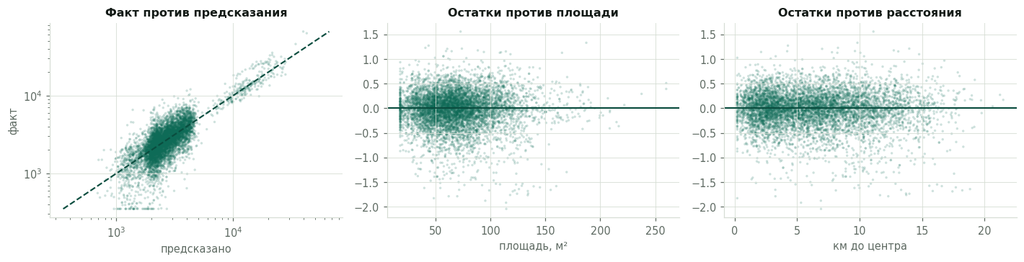

```
Медианный остаток по районам (медианная регрессия обнуляет именно его):
business        0.0002
central        -0.0003
green_zone     -0.0002
industrial     -0.0001
luxury_hills    0.0001
old_town        0.0002
residential    -0.0003
riverside      -0.0000
suburb          0.0001
university      0.0001
```

```python
fitted = np.exp(design_full @ COEF)
res_log = LOG_Y - np.log(fitted)

fig, ax = plt.subplots(1, 3, figsize=(13, 3.4))

ax[0].scatter(fitted, Y, s=5, color=ACCENT, alpha=.2, edgecolors="none")
lim = [Y.min(), Y.max()]
ax[0].plot(lim, lim, color="#0A4C3E", lw=1.4, ls="--")
ax[0].set_xscale("log"); ax[0].set_yscale("log")
ax[0].set_title("Факт против предсказания"); ax[0].set_xlabel("предсказано"); ax[0].set_ylabel("факт")

ax[1].scatter(train.area, res_log, s=5, color=ACCENT, alpha=.2, edgecolors="none")
ax[1].axhline(0, color="#0A4C3E", lw=1.4)
ax[1].set_title("Остатки против площади"); ax[1].set_xlabel("площадь, м²")

ax[2].scatter(train.distance_to_center, res_log, s=5, color=ACCENT, alpha=.2, edgecolors="none")
ax[2].axhline(0, color="#0A4C3E", lw=1.4)
ax[2].set_title("Остатки против расстояния"); ax[2].set_xlabel("км до центра")

plt.tight_layout(); plt.show()

by_district = pd.Series(res_log).groupby(train.district.values).median()
print("Медианный остаток по районам (медианная регрессия обнуляет именно его):")
print(by_district.round(4).to_string())
```

Посчитаем, какой результат был бы у идеальной модели, знающей истинную формулу.

```python
# Идеальная модель знала бы mu точно и всё равно ошибалась бы на величину шума.
# Оценим этот минимум напрямую: возьмём предсказания модели за истину и подмешаем
# к ним реальные остатки. Важно перемешивать остатки ВНУТРИ района — уровень шума
# в районах различается втрое, и общий пул исказил бы картину.
mu = design_full @ COEF
median_pred = np.exp(mu)

rng = np.random.default_rng(0)
rows_by_district = {d: np.where(train.district.values == d)[0] for d in DISTRICTS}

mae_floor, r2_floor = [], []
for _ in range(200):
    noise = np.empty(len(mu))
    for rows in rows_by_district.values():
        noise[rows] = rng.choice(res_log[rows], size=len(rows))
    fake = np.exp(mu + noise)
    mae_floor.append(mean_absolute_error(fake, median_pred))
    r2_floor.append(1 - ((fake - median_pred) ** 2).mean() / np.var(fake))

mae_floor = np.mean(mae_floor)
in_sample = mean_absolute_error(Y, np.clip(median_pred, PRICE_FLOOR, None))
best = summary.MAE.min()

print(f"σ шума в логарифмах:              {SIGMA:.4f}  (это ±{(np.exp(SIGMA)-1)*100:.0f} % к цене)")
print(f"Неустранимый минимум MAE:         {mae_floor:6.1f}   балл {points(mae_floor):.4f}")
print(f"MAE модели на самих обучающих:    {in_sample:6.1f}   балл {points(in_sample):.4f}")
print(f"MAE модели на кросс-валидации:    {best:6.1f}   балл {points(best):.4f}")
print(f"\nЗапас до предела: {best - mae_floor:.0f} единиц MAE, то есть {(best - mae_floor)/MAE_SCALE:.3f} балла.")
print(f"Потолок R² при таком шуме: {np.mean(r2_floor):.4f}")
```

```
σ шума в логарифмах:              0.3665  (это ±44 % к цене)
Неустранимый минимум MAE:          753.8   балл 0.4975
MAE модели на самих обучающих:     763.4   балл 0.4911
MAE модели на кросс-валидации:     773.5   балл 0.4844

Запас до предела: 20 единиц MAE, то есть 0.013 балла.
Потолок R² при таком шуме: 0.8399
```

Три числа выстраиваются в понятную картину. Неустранимый шум даёт около 754 единиц MAE — столько ошибалась бы модель, знающая истинную формулу наизусть. На обучающих данных наша модель показывает 763: разница в 9 единиц — это то, что она успела подогнать под конкретные 7000 строк. На кросс-валидации получается 773: ещё 10 единиц теряется на том, что коэффициенты приходится оценивать по конечной выборке.

Итого запаса на улучшения — около 20 единиц MAE, то есть **0.013 балла**. Даже идеальная модель набрала бы примерно 0.497 вместо наших 0.484. Это и есть главный практический вывод: задача решена настолько, насколько она вообще решается, и оставшееся время выгоднее потратить на другие темы квалификации.

## 8. Сабмит

Метрика конкурса — MAE, поэтому основной файл собирается медианной моделью. Заодно сохраняем запасной вариант под RMSE — на случай, если метрика где-то окажется другой.

```python
OUT = Path("..") / "submissions"
OUT.mkdir(exist_ok=True)

pred_main = predict_price(test)

# запасной вариант: МНК + поправка на логнормальность = условное среднее
beta_ls = np.linalg.lstsq(design_full, LOG_Y, rcond=None)[0]
sigma_ls = (LOG_Y - design_full @ beta_ls).std()
pred_alt = np.clip(np.exp(make_basis(test, DEGREE) @ beta_ls + 0.5 * sigma_ls ** 2), PRICE_FLOOR, None)

for filename, pred, note in (("submission_mae.csv", pred_main, "ОСНОВНОЙ — под MAE"),
                             ("submission_rmse.csv", pred_alt, "запасной — под RMSE/R²")):
    out = pd.DataFrame({"id": test.id, "rent_price": np.round(pred, 2)})
    out.to_csv(OUT / filename, index=False)

    assert list(out.columns) == list(sample.columns)
    assert (out.id.values == test.id.values).all()
    assert out.rent_price.notna().all() and len(out) == len(test)

    print(f"{filename:22s} строк {len(out)}   медиана {np.median(pred):7.1f}   {note}")

print("\nОтправлять на aiijc.com: submission_mae.csv")
pd.read_csv(OUT / "submission_mae.csv").head()
```

```
submission_mae.csv     строк 2000   медиана  2512.4   ОСНОВНОЙ — под MAE
submission_rmse.csv    строк 2000   медиана  2635.6   запасной — под RMSE/R²

Отправлять на aiijc.com: submission_mae.csv
```

|  | id | rent_price |
| --- | --- | --- |
| 0 | 7000 | 2459.03 |
| 1 | 7001 | 2805.53 |
| 2 | 7002 | 4114.17 |
| 3 | 7003 | 1149.00 |
| 4 | 7004 | 2450.96 |

## 9. Выводы

**1. Данные синтетические, и формула восстанавливается.** Цена собирается как произведение: базовый уровень района × площадь в степени × экспонента от расстояния × слабая поправка на этаж × логнормальный шум, затем обрезка снизу на 350. После логарифмирования всё становится линейным.

**2. Решает одно взаимодействие — `district` × `area`.** Эластичность по площади меняется от +1.02 в `luxury_hills` до −0.26 в `university`. Именно оно даёт основной скачок качества.

**5. Есть жёсткий потолок, и мы его посчитали.** Шум мультипликативный, σ ≈ 0.37 в логарифмах. Неустранимый минимум MAE ≈ 754, наш результат ≈ 773. Запас — 0.013 балла, из которых часть принципиально недостижима. Это доказано расчётом, а не предположено.

### Что можно сделать дальше

Все три идеи дадут единицы MAE, то есть тысячные доли балла — при запасе до предела в 0.013. Потолок близко, и это главный практический вывод работы.